# Transitions Bibliometrics 2020

Daniel S. Hain

13 September, 2021

# 1 Initial Corpus generation

# 2 General Overview over EIST articles

## 2.1 Main Indicators: Publications, Authors, Countries

To start with, a general overview over the documents in the corpus.

```
MAIN INFORMATION ABOUT DATA

 Timespan                              2011 : 2021
 Sources (Journals, Books, etc)        1
 Documents                             479
 Average years from publication        3.68
 Average citations per documents       29.15
 Average citations per year per doc    5.368
 References                            31206

DOCUMENT TYPES
 article               432
 conference paper      30
 editorial             6
 note                  3
 short survey          8

DOCUMENT CONTENTS
 Keywords Plus (ID)                    929
 Author's Keywords (DE)                1527

AUTHORS
 Authors                               946
 Author Appearances                    1274
 Authors of single-authored documents  110
 Authors of multi-authored documents   836

AUTHORS COLLABORATION
 Single-authored documents             118
 Documents per Author                  0.506
 Authors per Document                  1.97
 Co-Authors per Documents              2.66
 Collaboration Index                   2.32


Annual Scientific Production
```

| Year | Articles |
| --- | --- |
| 2011 | 22 |
| 2012 | 20 |
| 2013 | 25 |
| 2014 | 24 |
| 2015 | 49 |
| 2016 | 38 |
| 2017 | 36 |
| 2018 | 47 |
| 2019 | 52 |
| 2020 | 120 |

[output cut: 1 more lines]

```
Annual Percentage Growth Rate 7.654829


Most Productive Authors
```

|  | Authors | Articles | Authors | Articles Fractionalized |
| --- | --- | --- | --- | --- |
| 1 | HEKKERT MP | 12 | VAN DEN BERGH JCJM | 3.83 |
| 2 | RAVEN R | 12 | PAPACHRISTOS G | 3.76 |
| 3 | TRUFFER B | 10 | GEELS FW | 3.62 |
| 4 | KERN F | 9 | HEKKERT MP | 3.53 |
| 5 | KHLER J | 9 | TRUFFER B | 3.33 |
| 6 | KIVIMAA P | 8 | KHLER J | 3.16 |
| 7 | SOVACOOL BK | 8 | KERN F | 3.07 |
| 8 | ALKEMADE F | 7 | RAVEN R | 3.05 |
| 9 | BOON WPC | 7 | SOVACOOL BK | 2.83 |
| 10 | GEELS FW | 7 | HESS DJ | 2.75 |

```
Top manuscripts per citations
```

|  | Paper | DOI | TC | TCperYear | NTC |
| --- | --- | --- | --- | --- | --- |
| 1 | GEELS FW, 2011, ENVIRONMENTAL INNOVATION AND SOCIETAL TRANSITIONS | 10.1016/j.eist.2011.02.002 | 1070 | 97.3 | 9.17 |
| 2 | FRENKEN K, 2017, ENVIRONMENTAL INNOVATION AND SOCIETAL TRANSITIONS | 10.1016/j.eist.2017.01.003 | 415 | 83.0 | 8.23 |
| 3 | KHLER J, 2019, ENVIRONMENTAL INNOVATION AND SOCIETAL TRANSITIONS | 10.1016/j.eist.2019.01.004 | 374 | 124.7 | 20.82 |
| 4 | HANSEN T, 2015, ENVIRONMENTAL INNOVATION AND SOCIETAL TRANSITIONS | 10.1016/j.eist.2014.11.001 | 315 | 45.0 | 6.44 |
| 5 | MEADOWCROFT J, 2011, ENVIRONMENTAL INNOVATION AND SOCIETAL TRANSITIONS | 10.1016/j.eist.2011.02.003 | 308 | 28.0 | 2.64 |
| 6 | JACOBSSON S, 2011, ENVIRONMENTAL INNOVATION AND SOCIETAL TRANSITIONS | 10.1016/j.eist.2011.04.006 | 249 | 22.6 | 2.13 |
| 7 | VAN DEN BERGH JCJM, 2011, ENVIRONMENTAL INNOVATION AND SOCIETAL TRANSITIONS | 10.1016/j.eist.2011.04.010 | 243 | 22.1 | 2.08 |
| 8 | BCKER L, 2017, ENVIRONMENTAL INNOVATION AND SOCIETAL TRANSITIONS | 10.1016/j.eist.2016.09.004 | 232 | 46.4 | 4.60 |
| 9 | RAVENA R, 2012, ENVIRONMENTAL INNOVATION AND SOCIETAL TRANSITIONS | 10.1016/j.eist.2012.08.001 | 230 | 23.0 | 4.66 |
| 10 | SEYFANG G, 2014, ENVIRONMENTAL INNOVATION AND SOCIETAL TRANSITIONS | 10.1016/j.eist.2014.04.004 | 201 | 25.1 | 6.15 |

```
Corresponding Author's Countries
```

|  | Country | Articles | Freq | SCP | MCP | MCP_Ratio |
| --- | --- | --- | --- | --- | --- | --- |
| 1 | NETHERLANDS | 82 | 0.2055 | 49 | 33 | 0.402 |
| 2 | UNITED KINGDOM | 65 | 0.1629 | 38 | 27 | 0.415 |
| 3 | GERMANY | 53 | 0.1328 | 34 | 19 | 0.358 |
| 4 | SWEDEN | 35 | 0.0877 | 29 | 6 | 0.171 |
| 5 | USA | 27 | 0.0677 | 23 | 4 | 0.148 |
| 6 | SWITZERLAND | 17 | 0.0426 | 7 | 10 | 0.588 |
| 7 | NORWAY | 14 | 0.0351 | 9 | 5 | 0.357 |
| 8 | AUSTRALIA | 12 | 0.0301 | 9 | 3 | 0.250 |
| 9 | FINLAND | 12 | 0.0301 | 9 | 3 | 0.250 |
| 10 | SPAIN | 10 | 0.0251 | 4 | 6 | 0.600 |

```
SCP: Single Country Publications

MCP: Multiple Country Publications


Total Citations per Country
```

|  | Country | Total Citations | Average Article Citations |
| --- | --- | --- | --- |
| 1 | NETHERLANDS | 3107 | 37.89 |
| 2 | UNITED KINGDOM | 2702 | 41.57 |
| 3 | SWEDEN | 1439 | 41.11 |
| 4 | GERMANY | 1400 | 26.42 |
| 5 | USA | 773 | 28.63 |
| 6 | SWITZERLAND | 686 | 40.35 |
| 7 | SPAIN | 425 | 42.50 |
| 8 | CANADA | 392 | 56.00 |
| 9 | NORWAY | 321 | 22.93 |
| 10 | AUSTRIA | 217 | 27.12 |

```
Most Relevant Sources
```

|  | Sources | Articles |
| --- | --- | --- |
| 1 | ENVIRONMENTAL INNOVATION AND SOCIETAL TRANSITIONS | 479 |

```
Most Relevant Keywords
```

|  | Author Keywords (DE) | Articles | Keywords-Plus (ID) | Articles |
| --- | --- | --- | --- | --- |
| 1 | SUSTAINABILITY TRANSITIONS | 67 | SUSTAINABILITY | 194 |
| 2 | SUSTAINABILITY | 32 | INNOVATION | 146 |
| 3 | TRANSITIONS | 31 | GOVERNANCE APPROACH | 52 |
| 4 | MULTI-LEVEL PERSPECTIVE | 29 | SUSTAINABLE DEVELOPMENT | 52 |
| 5 | INNOVATION | 24 | CONCEPTUAL FRAMEWORK | 42 |
| 6 | TRANSITION | 24 | POLICY MAKING | 40 |
| 7 | ENERGY TRANSITION | 23 | LITERATURE REVIEW | 37 |
| 8 | RENEWABLE ENERGY | 21 | UNITED KINGDOM | 37 |
| 9 | GOVERNANCE | 17 | RESEARCH WORK | 36 |
| 10 | SUSTAINABILITY TRANSITION | 16 | STRATEGIC APPROACH | 32 |

```
NA
```

And a graphical visualization

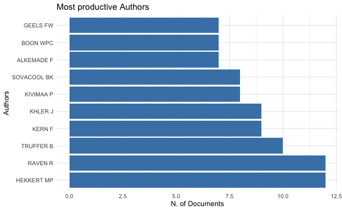

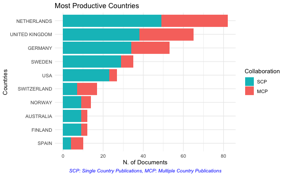

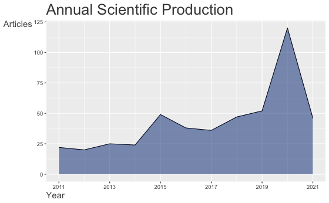

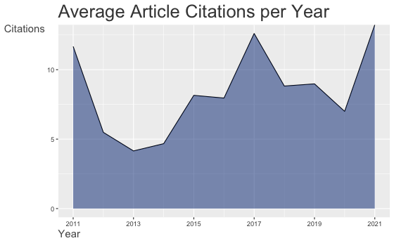

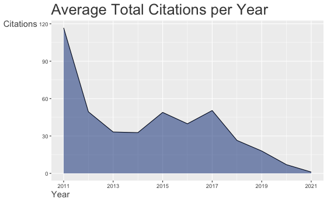

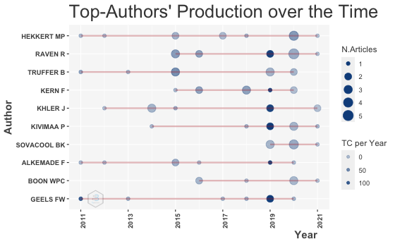

[figure not shown]

## 2.2 Cited references

Top 20 cited references (by corpus documents):

| CR | n |
| --- | --- |
| GEELS, F.W., TECHNOLOGICAL TRANSITIONS AS EVOLUTIONARY RECONFIGURATION PROCESSES: A MULTI-LEVEL PERSPECTIVE AND A CASE-STUDY (2002) RES. POLICY, 31, PP. 1257-1274 | 60 |
| MARKARD, J., RAVEN, R., TRUFFER, B., SUSTAINABILITY TRANSITIONS: AN EMERGING FIELD OF RESEARCH AND ITS PROSPECTS (2012) RES. POLICY, 41, PP. 955-967 | 52 |
| GEELS, F.W., SCHOT, J., TYPOLOGY OF SOCIOTECHNICAL TRANSITION PATHWAYS (2007) RES. POLICY, 36, PP. 399-417 | 47 |
| MARKARD, J., RAVEN, R., TRUFFER, B., SUSTAINABILITY TRANSITIONS: AN EMERGING FIELD OF RESEARCH AND ITS PROSPECTS (2012) RES. POLICY, 41 (6), PP. 955-967 | 44 |
| SMITH, A., RAVEN, R., WHAT IS PROTECTIVE SPACE? RECONSIDERING NICHES IN TRANSITIONS TO SUSTAINABILITY (2012) RES. POLICY, 41, PP. 1025-1036 | 42 |
| GEELS, F.W., SCHOT, J., TYPOLOGY OF SOCIOTECHNICAL TRANSITION PATHWAYS (2007) RES. POLICY, 36 (3), PP. 399-417 | 37 |
| SMITH, A., RAVEN, R., WHAT IS PROTECTIVE SPACE? RECONSIDERING NICHES IN TRANSITIONS TO SUSTAINABILITY (2012) RES. POLICY, 41 (6), PP. 1025-1036 | 37 |
| GEELS, F.W., TECHNOLOGICAL TRANSITIONS AS EVOLUTIONARY RECONFIGURATION PROCESSES: A MULTI-LEVEL PERSPECTIVE AND A CASE-STUDY (2002) RES. POLICY, 31 (8-9), PP. 1257-1274 | 34 |
| BERGEK, A., JACOBSSON, S., CARLSSON, B., LINDMARK, S., RICKNE, A., ANALYZING THE FUNCTIONAL DYNAMICS OF TECHNOLOGICAL INNOVATION SYSTEMS: A SCHEME OF ANALYSIS (2008) RES. POLICY, 37, PP. 407-429 | 30 |
| GEELS, F.W., FROM SECTORAL SYSTEMS OF INNOVATION TO SOCIO-TECHNICAL SYSTEMS: INSIGHTS ABOUT DYNAMICS AND CHANGE FROM SOCIOLOGY AND INSTITUTIONAL THEORY (2004) RES. POLICY, 33, PP. 897-920 | 27 |
| SMITH, A., STIRLING, A., BERKHOUT, F., THE GOVERNANCE OF SUSTAINABLE SOCIO-TECHNICAL TRANSITIONS (2005) RES. POLICY, 34, PP. 1491-1510 | 25 |
| UNRUH, G.C., UNDERSTANDING CARBON LOCK-IN (2000) ENERGY POLICY, 28, PP. 817-830 | 24 |
| COENEN, L., BENNEWORTH, P., TRUFFER, B., TOWARD A SPATIAL PERSPECTIVE ON SUSTAINABILITY TRANSITIONS (2012) RES. POLICY, 41, PP. 968-979 | 23 |
| GEELS, F.W., THE MULTI-LEVEL PERSPECTIVE ON SUSTAINABILITY TRANSITIONS: RESPONSES TO SEVEN CRITICISMS (2011) ENVIRON. INNOV. SOC. TRANSIT., 1, PP. 24-40 | 23 |
| MARKARD, J., TRUFFER, B., TECHNOLOGICAL INNOVATION SYSTEMS AND THE MULTI-LEVEL PERSPECTIVE: TOWARDS AN INTEGRATED FRAMEWORK (2008) RES. POLICY, 37, PP. 596-615 | 22 |
| COENEN, L., BENNEWORTH, P., TRUFFER, B., TOWARD A SPATIAL PERSPECTIVE ON SUSTAINABILITY TRANSITIONS (2012) RES. POLICY, 41 (6), PP. 968-979 | 21 |
| SMITH, A., STIRLING, A., BERKHOUT, F., THE GOVERNANCE OF SUSTAINABLE SOCIO-TECHNICAL TRANSITIONS (2005) RES. POLICY, 34 (10), PP. 1491-1510 | 21 |
| ROTMANS, J., KEMP, R., VAN ASSELT, M., MORE EVOLUTION THAN REVOLUTION: TRANSITION MANAGEMENT IN PUBLIC POLICY (2001) FORESIGHT, 3 (1), PP. 15-31 | 20 |
| MARKARD, J., TRUFFER, B., TECHNOLOGICAL INNOVATION SYSTEMS AND THE MULTI-LEVEL PERSPECTIVE: TOWARDS AN INTEGRATED FRAMEWORK (2008) RES. POLICY, 37 (4), PP. 596-615 | 19 |
| KIVIMAA, P., KERN, F., CREATIVE DESTRUCTION OR MERE NICHE SUPPORT? INNOVATION POLICY MIXES FOR SUSTAINABILITY TRANSITIONS (2016) RES. POLICY, 45 (1), PP. 205-217 | 18 |

# 3 Topic modelling

I by now created some topic modelling. The results are now more fine-tuned, but there is still room for some improvement. We ran a LDA on the titles + abstracts of our corpus, aiming at identifying 6 topics (different evaluation methods point towards this number)

## 3.1 Topics by topwords

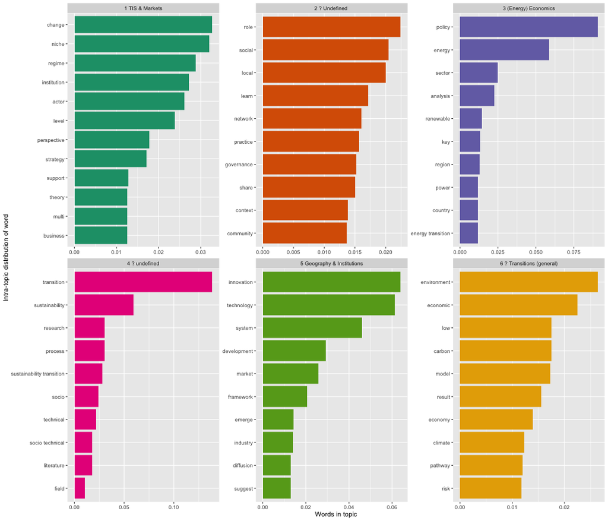

This might still be finetuned, but initially doesnt look that bad I think. All the topics for me seem to be somewhat identifiable. We should maybe start naming them to make their interpretation later easier.

## 3.2 Topics over time

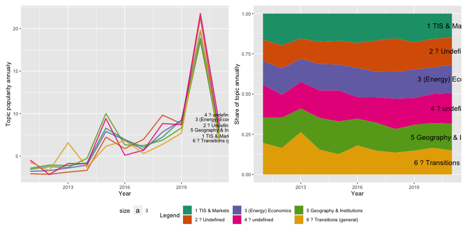

## 3.3 LDAViz

Here you find a nice way of exploring topics via the `LDAVIz` methodology of visulizing the result of an LDA. It dispolays all topics in a 2 dimensional TSNE (similar to PCA, but optimized for graphical illustration in 2d), and also gives a nice visual representation over the topics top-word distribution and overall frequencies of this words in the corpus. The $\lambda$ parameter regulates the importance-ordering of the topwords. High $\lambda$ order words by the highest propability to appear in the topic to the lowest (independent of the overall word popularity in the corpus), whle low $\lambda$ emphasize words which are very specific to the topic, and rarely appear in others.

Play a bit around. Since it would be here a bit condensed, here in fullscreen for a better overview. I also provide besides the 6 topics version I presented above a version with 8 or 10 topics to inspect which fits best.

- [6 Topics](https://daniel-hain.github.io/bibliometrics_EIST_2021/output/LDAviz6/)
- [8 Topics](https://daniel-hain.github.io/bibliometrics_EIST_2021/output/LDAviz8/)
- [10 Topics](https://daniel-hain.github.io/bibliometrics_EIST_2021/output/LDAviz10/)

# 4 Knowledge Bases: Co-Citation network analysis

**Note:** This analysis refers the co-citation analysis, where the cited references and not the original publications are the unit of analysis. See tab `Technical description`for additional explanations

## 4.1 Knowledge Bases summary

### 4.1.1 Main Indicators

In order to partition networks into components or clusters, we deploy a **community detection** technique based on the **Lovain Algorithm** (Blondel et al., 2008). The Lovain Algorithm is a heuristic method that attempts to optimize the modularity of communities within a network by maximizing within- and minimizing between-community connectivity. We identify the following communities = knowledge bases.

| com_name | n | density_int |
| --- | --- | --- |
| 1 MLP | 682 | 7.137 |
| 2 TIS | 243 | 18.913 |
| 3 Geography | 241 | 11.075 |
| 4 Intermediaries | 168 | 21.400 |
| 5 Modelling | 126 | 22.832 |
| 6 ? Undefined (diffusion) | 116 | 15.967 |
| 7 Sociology1 | 101 | 30.515 |
| 8 Management | 78 | 82.850 |
| 9 Sharing Economy | 55 | 28.485 |

It is not the main focus of this exercise, but still informative to see which historical knowledge the fields draws from.

NOTE: Up to now I only report the most central members per community

| com | name | dgr_int | dgr |
| --- | --- | --- | --- |
| 1 | GEELS F.W. TECHNOLOGICAL TRANSITIONS AS EVOLUTIONARY RECONFIGURATION PROCESSES: A MULTI-LEVEL PERSPECTIVE AND A CASE-STUDY (2002) | 1531 | 3062 |
| 1 | GEELS F.W. SCHOT J. TYPOLOGY OF SOCIOTECHNICAL TRANSITION PATHWAYS (2007) | 1495 | 2629 |
| 1 | SMITH A. RAVEN R. WHAT IS PROTECTIVE SPACE? RECONSIDERING NICHES IN TRANSITIONS TO SUSTAINABILITY (2012) | 1120 | 2333 |
| 1 | GEELS F.W. THE MULTI-LEVEL PERSPECTIVE ON SUSTAINABILITY TRANSITIONS: RESPONSES TO SEVEN CRITICISMS (2011) | 991 | 1781 |
| 1 | SMITH A. STIRLING A. BERKHOUT F. THE GOVERNANCE OF SUSTAINABLE SOCIO-TECHNICAL TRANSITIONS (2005) | 835 | 1242 |
| 1 | GEELS F.W. REGIME RESISTANCE AGAINST LOW-CARBON TRANSITIONS: INTRODUCING POLITICS AND POWER INTO THE MULTI-LEVEL PERSPECTIVE (2014) | 706 | 985 |
| 1 | GEELS F.W. FROM SECTORAL SYSTEMS OF INNOVATION TO SOCIO-TECHNICAL SYSTEMS: INSIGHTS ABOUT DYNAMICS AND CHANGE FROM SOCIOLOGY AND INSTITUTIONAL THEO... | 648 | 1025 |
| 1 | RIP A. KEMP R. TECHNOLOGICAL CHANGE (1998) | 634 | 1182 |
| 1 | UNRUH G.C. UNDERSTANDING CARBON LOCK-IN (2000) | 616 | 905 |
| 1 | FARLA J. MARKARD J. RAVEN R. COENEN L. SUSTAINABILITY TRANSITIONS IN THE MAKING: A CLOSER LOOK AT ACTORS STRATEGIES AND RESOURCES (2012) | 605 | 1106 |
| 2 | BERGEK A. JACOBSSON S. CARLSSON B. LINDMARK S. RICKNE A. ANALYZING THE FUNCTIONAL DYNAMICS OF TECHNOLOGICAL INNOVATION SYSTEMS: A SCHEME OF ANALYSI... | 700 | 1369 |
| 2 | MARKARD J. TRUFFER B. TECHNOLOGICAL INNOVATION SYSTEMS AND THE MULTI-LEVEL PERSPECTIVE: TOWARDS AN INTEGRATED FRAMEWORK (2008) | 450 | 1149 |
| 2 | CARLSSON B. STANKIEWICZ R. ON THE NATURE FUNCTION AND COMPOSITION OF TECHNOLOGICAL SYSTEMS (1991) | 406 | 599 |
| 2 | HEKKERT M.P. SUURS R.A.A. NEGRO S.O. KUHLMANN S. SMITS R.E.H.M. FUNCTIONS OF INNOVATION SYSTEMS: A NEW APPROACH FOR ANALYSING TECHNOLOGICAL CHANGE ... | 330 | 767 |
| 2 | JACOBSSON S. BERGEK A. INNOVATION SYSTEM ANALYSES AND SUSTAINABILITY TRANSITIONS: CONTRIBUTIONS AND SUGGESTIONS FOR RESEARCH (2011) | 282 | 536 |
| 2 | JACOBSSON S. BERGEK A. TRANSFORMING THE ENERGY SECTOR: THE EVOLUTION OF TECHNOLOGICAL SYSTEMS IN RENEWABLE ENERGY TECHNOLOGY (2004) | 267 | 413 |
| 2 | DEWALD U. TRUFFER B. THE LOCAL SOURCES OF MARKET FORMATION: EXPLAINING REGIONAL GROWTH DIFFERENTIALS IN GERMAN PHOTOVOLTAIC MARKETS (2012) | 213 | 436 |
| 2 | BERGEK A. HEKKERT M. JACOBSSON S. MARKARD J. SANDN B. TRUFFER B. TECHNOLOGICAL INNOVATION SYSTEMS IN CONTEXTS: CONCEPTUALIZING CONTEXTUAL STRUCTURE... | 210 | 391 |
| 2 | BINZ C. TRUFFER B. GLOBAL INNOVATION SYSTEMSA CONCEPTUAL FRAMEWORK FOR INNOVATION DYNAMICS IN TRANSNATIONAL CONTEXTS (2017) | 196 | 267 |
| 2 | MUSIOLIK J. MARKARD J. CREATING AND SHAPING INNOVATION SYSTEMS: FORMAL NETWORKS IN THE INNOVATION SYSTEM FOR STATIONARY FUEL CELLS IN GERMANY (2011) | 192 | 295 |
| 3 | MARKARD J. RAVEN R. TRUFFER B. SUSTAINABILITY TRANSITIONS: AN EMERGING FIELD OF RESEARCH AND ITS PROSPECTS (2012) | 481 | 2724 |
| 3 | COENEN L. BENNEWORTH P. TRUFFER B. TOWARD A SPATIAL PERSPECTIVE ON SUSTAINABILITY TRANSITIONS (2012) | 383 | 1184 |
| 3 | RAVEN R. SCHOT J. BERKHOUT F. SPACE AND SCALE IN SOCIO-TECHNICAL TRANSITIONS (2012) | 304 | 645 |
| 3 | HODSON M. MARVIN S. CAN CITIES SHAPE SOCIO-TECHNICAL TRANSITIONS AND HOW WOULD WE KNOW IF THEY WERE? (2010) | 298 | 721 |
| 3 | HANSEN T. COENEN L. THE GEOGRAPHY OF SUSTAINABILITY TRANSITIONS: REVIEW SYNTHESIS AND REFLECTIONS ON AN EMERGENT RESEARCH FIELD (2015) | 256 | 633 |
| 3 | TRUFFER B. COENEN L. ENVIRONMENTAL INNOVATION AND SUSTAINABILITY TRANSITIONS IN REGIONAL STUDIES (2012) | 216 | 581 |
| 3 | COENEN L. TRUFFER B. PLACES AND SPACES OF SUSTAINABILITY TRANSITIONS: GEOGRAPHICAL CONTRIBUTIONS TO AN EMERGING RESEARCH AND POLICY FIELD (2012) | 158 | 292 |
| 3 | MURPHY J.T. HUMAN GEOGRAPHY AND SOCIO-TECHNICAL TRANSITION STUDIES: PROMISING INTERSECTIONS (2015) | 136 | 210 |
| 3 | TRUFFER B. MURPHY J.T. RAVEN R. THE GEOGRAPHY OF SUSTAINABILITY TRANSITIONS: CONTOURS OF AN EMERGING THEME (2015) | 118 | 261 |
| 3 | CASTN BROTO V. BULKELEY H. A SURVEY OF URBAN CLIMATE CHANGE EXPERIMENTS IN 100 CITIES (2013) | 117 | 177 |

[output cut: 60 more lines]

### 4.1.2 Development of Knowledge Bases

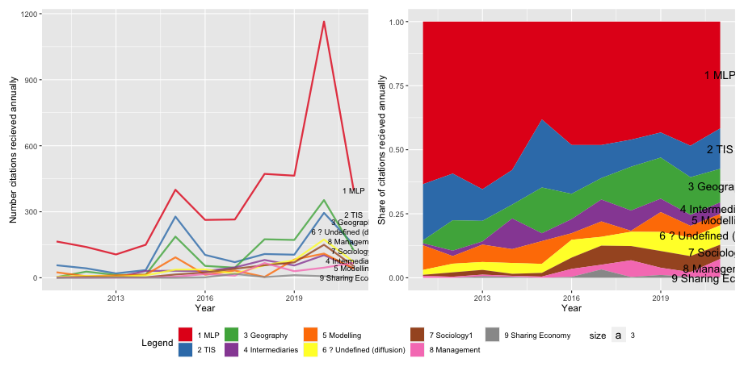

## 4.2 Technical description

In a co-cittion network, the strength of the relationship between a reference pair $m$ and $n$ ($s_{m,n}^{coc}$) is expressed by the number of publications $C$ which are jointly citing reference $m$ and $n$.

$$s_{m,n}^{coc} = \sum_i c_{i,m} c_{i,n}$$

The intuition here is that references which are frequently cited together are likely to share commonalities in theory, topic, methodology, or context. It can be interpreted as a measure of similarity as evaluated by other researchers that decide to jointly cite both references. Because the publication process is time-consuming, co-citation is a backward-looking measure, which is appropriate to map the relationship between core literature of a field.

# 5 Research Areas: Bibliographic coupling analysis

## 5.1 Research Areas main summary

This is arguably the more interesting part. Here, we identify the literature’s current knowledge frontier by carrying out a bibliographic coupling analysis of the publications in our corpus. This measure uses bibliographical information of publications to establish a similarity relationship between them. Again, method details to be found in the tab `Technical description`. As you will see, we identify the more narrow research community of Sustainability Transitions (in which we will zoom in later), but also a set of adjacent research areas with some theoretical/methodological/application overlap.

### 5.1.1 Main Characteristics

To identify communities in the field’s knowledge frontier (labeled **research areas**) we again use the **Lovain Algorithm** (Blondel et al., 2008). We identify the following communities = research areas.

| com | com_name | n | density_int |
| --- | --- | --- | --- |
| 1 | 1 MLP / TIS | 124 | 109.927 |
| 2 | 2 MLP | 121 | 147.617 |
| 3 | 3 Geography | 99 | 135.642 |
| 4 | 4 Policy | 78 | 101.765 |

| com | com_name | topic_name |
| --- | --- | --- |
| 1 | 1 MLP / TIS | 6 ? Transitions (general) |
| 1 | 1 MLP / TIS | 5 Geography & Institutions |
| 1 | 1 MLP / TIS | 1 TIS & Markets |
| 2 | 2 MLP | 1 TIS & Markets |
| 2 | 2 MLP | 2 ? Undefined |
| 2 | 2 MLP | 4 ? undefined |
| 3 | 3 Geography | 5 Geography & Institutions |
| 3 | 3 Geography | 4 ? undefined |
| 3 | 3 Geography | 3 (Energy) Economics |
| 4 | 4 Policy | 3 (Energy) Economics |
| 4 | 4 Policy | 4 ? undefined |
| 4 | 4 Policy | 2 ? Undefined |
| NA | NA | 2 ? Undefined |
| NA | NA | 6 ? Transitions (general) |
| NA | NA | 3 (Energy) Economics |

## 5.2 Technical description

In a bibliographic coupling network, the **coupling-strength** between publications is determined by the number of commonly cited references they share, assuming a common pool of references to indicate similarity in context, methods, or theory. Formally, the strength of the relationship between a publication pair $i$ and $j$ ($s_{i,j}^{bib}$) is expressed by the number of commonly cited references.

$$s_{i,j}^{bib} = \sum_m c_{i,m} c_{j,m}$$

Since our corpus contains publications which differ strongly in terms of the number of cited references, we normalize the coupling strength by the Jaccard similarity coefficient. Here, we weight the intercept of two publications’ bibliography (shared refeences) by their union (number of all references cited by either $i$ or $j$). It is bounded between zero and one, where one indicates the two publications to have an identical bibliography, and zero that they do not share any cited reference. Thereby, we prevent publications from having high coupling strength due to a large bibliography (e.g., literature surveys).

$$S_{i,j}^{jac-bib} =\frac{C(i \cap j)}{C(i \cup j)} = \frac{s_{i,j}^{bib}}{c_i + c_j - s_{i,j}^{bib}}$$

More recent articles have a higher pool of possible references to co-cite to, hence they are more likely to be coupled. Consequently, bibliographic coupling represents a forward looking measure, and the method of choice to identify the current knowledge frontier at the point of analysis.